# Python Basics for Data Science

- Show All Code
- Hide All Code
- View Source

Author

Portfolio 2026

Published

March 13, 2026

# Part 1: Python Fundamentals

## 1.1 Variables and Data Types

Python is dynamically typed — you do not declare types explicitly.

```python
# Assignment
gene_name = "BRCA1"
expression_value = 42.7
is_upregulated = True
sample_count = 6

# Check types
print(type(gene_name))       # <class 'str'>
print(type(expression_value)) # <class 'float'>
print(type(is_upregulated))   # <class 'bool'>
print(type(sample_count))     # <class 'int'>
```

```
<class 'str'>
<class 'float'>
<class 'bool'>
<class 'int'>
```

### Numeric Types

```python
# Integers have arbitrary precision
large_genome = 3_000_000_000  # underscores for readability
print(large_genome)

# Float arithmetic
print(0.1 + 0.2)             # floating-point caveat: 0.30000000000000004

# Integer division vs true division
print(7 // 2)                # 3  (floor division)
print(7 / 2)                 # 3.5
print(7 % 2)                 # 1  (modulo)
print(2 ** 10)               # 1024 (exponentiation)
```

```
3000000000
0.30000000000000004
3
3.5
1
1024
```

### Strings

```python
sequence = "ATGCGCTA"

# String methods
print(sequence.lower())
print(sequence.count("GC"))
print(sequence.replace("A", "U"))  # DNA → RNA (simplified)
print(len(sequence))

# f-strings (formatted string literals)
gc_count = sequence.count("G") + sequence.count("C")
gc_pct = gc_count / len(sequence) * 100
print(f"GC content: {gc_pct:.1f}%")

# Slicing
print(sequence[0:3])         # first codon: ATG
print(sequence[-3:])         # last codon: CTA
print(sequence[::-1])        # reverse: ATCGCGTA
```

```
atgcgcta
2
UTGCGCTU
8
GC content: 50.0%
ATG
CTA
ATCGCGTA
```

### Special Values

```python
import math

print(None)                  # Python's null
print(float("nan"))          # NaN
print(float("inf"))          # Infinity
print(math.isnan(float("nan")))
print(math.isinf(float("inf")))

# None checks
x = None
print(x is None)             # always use 'is', not '=='
```

```
None
nan
inf
True
True
True
```

### Type Conversion

```python
print(int("42"))
print(float("3.14"))
print(str(100))
print(bool(0))               # False
print(bool("non-empty"))     # True
print(bool([]))              # False (empty container)
print(bool([1]))             # True
```

```
42
3.14
100
False
True
False
True
```

## 1.2 Lists

Lists are ordered, mutable collections that can hold mixed types.

```python
gene_lengths = [1863, 5592, 2487, 945, 3210]
samples = ["ctrl_1", "ctrl_2", "treat_1", "treat_2"]

# Indexing (0-based)
print(gene_lengths[0])       # first: 1863
print(gene_lengths[-1])      # last: 3210
print(gene_lengths[1:3])     # slice: [5592, 2487]

# Modify in place
gene_lengths.append(4100)
gene_lengths.extend([720, 1340])
gene_lengths.sort()
print(gene_lengths)

# List comprehension — the Pythonic way
lengths_kb = [g / 1000 for g in gene_lengths]
print(lengths_kb)

# Filtered comprehension
long_genes = [g for g in gene_lengths if g > 2000]
print(long_genes)
```

```
1863
3210
[5592, 2487]
[720, 945, 1340, 1863, 2487, 3210, 4100, 5592]
[0.72, 0.945, 1.34, 1.863, 2.487, 3.21, 4.1, 5.592]
[2487, 3210, 4100, 5592]
```

### Useful List Operations

```python
nums = [10, 20, 30, 40, 50]

print(len(nums))
print(sum(nums))
print(min(nums), max(nums))
print(sorted(nums, reverse=True))

# Enumerate — get index and value
for i, val in enumerate(nums):
    print(f"  Index {i}: {val}")

# Zip — pair elements from two lists
genes = ["BRCA1", "TP53", "MYC"]
pvals = [0.001, 0.05, 0.0003]
for gene, p in zip(genes, pvals):
    print(f"  {gene}: p={p}")
```

```
5
150
10 50
[50, 40, 30, 20, 10]
  Index 0: 10
  Index 1: 20
  Index 2: 30
  Index 3: 40
  Index 4: 50
  BRCA1: p=0.001
  TP53: p=0.05
  MYC: p=0.0003
```

## 1.3 Tuples

Tuples are immutable sequences — use them for fixed collections and as dictionary keys.

```python
coordinates = (17, 43044295, 43170245)  # chr, start, end
chrom, start, end = coordinates          # unpacking
print(f"Chromosome {chrom}: {start:,}-{end:,}")

# Tuples are immutable
# coordinates[0] = 1  # would raise TypeError
```

```
Chromosome 17: 43,044,295-43,170,245
```

## 1.4 Dictionaries

Dictionaries store key-value pairs with O(1) lookup.

```python
gene_info = {
    "name": "BRCA1",
    "chromosome": "chr17",
    "length": 81189,
    "biotype": "protein_coding",
}

# Access
print(gene_info["name"])
print(gene_info.get("strand", "unknown"))  # default if missing

# Modify
gene_info["strand"] = "+"
gene_info["length"] = 81189

# Iterate
for key, value in gene_info.items():
    print(f"  {key}: {value}")

# Dictionary comprehension
expression = {"BRCA1": 12.3, "TP53": 8.7, "MYC": 45.1, "EGFR": 22.0}
high_expr = {g: v for g, v in expression.items() if v > 15}
print(high_expr)
```

```
BRCA1
unknown
  name: BRCA1
  chromosome: chr17
  length: 81189
  biotype: protein_coding
  strand: +
{'MYC': 45.1, 'EGFR': 22.0}
```

## 1.5 Sets

Sets are unordered collections of unique elements — useful for membership testing and set operations on gene lists.

```python
deg_up = {"BRCA1", "MYC", "EGFR", "KRAS"}
deg_down = {"TP53", "RB1", "MYC", "APC"}

print(deg_up & deg_down)     # intersection
print(deg_up | deg_down)     # union
print(deg_up - deg_down)     # difference
print("BRCA1" in deg_up)     # membership test: O(1)
```

```
{'MYC'}
{'APC', 'MYC', 'RB1', 'TP53', 'KRAS', 'EGFR', 'BRCA1'}
{'KRAS', 'EGFR', 'BRCA1'}
True
```

## 1.6 Control Flow

### Conditionals

```python
pvalue = 0.03

if pvalue < 0.001:
    significance = "***"
elif pvalue < 0.01:
    significance = "**"
elif pvalue < 0.05:
    significance = "*"
else:
    significance = "ns"

print(f"p = {pvalue} → {significance}")

# Ternary expression
direction = "up" if 2.1 > 0 else "down"
print(direction)
```

```
p = 0.03 → *
up
```

### Loops

```python
# For loop
genes = ["BRCA1", "TP53", "MYC"]
for gene in genes:
    print(f"Processing: {gene}")

# While loop with break
import random
random.seed(42)
attempts = 0
while True:
    val = random.random()
    attempts += 1
    if val > 0.95:
        break
print(f"Took {attempts} attempts to exceed 0.95")

# continue — skip an iteration
for i in range(10):
    if i % 2 == 0:
        continue
    print(i, end=" ")
print()
```

```
Processing: BRCA1
Processing: TP53
Processing: MYC
Took 25 attempts to exceed 0.95
1 3 5 7 9
```

## 1.7 Functions

```python
def gc_content(sequence: str) -> float:
    """Calculate the GC content of a DNA sequence.

    Args:
        sequence: A string of DNA bases (A, T, G, C).

    Returns:
        The fraction of G and C bases in the sequence.
    """
    seq = sequence.upper()
    gc = seq.count("G") + seq.count("C")
    return gc / len(seq)

print(gc_content("ATGCGCTA"))
print(gc_content("AAATTTAAA"))
```

```
0.5
0.0
```

### Default Arguments and *args/**kwargs

```python
def normalize(values: list[float], method: str = "zscore") -> list[float]:
    """Normalize a list of values.

    Args:
        values: Numeric values to normalize.
        method: Normalization method — 'zscore' or 'minmax'.

    Returns:
        Normalized values as a list.
    """
    import statistics

    if method == "zscore":
        mu = statistics.mean(values)
        sigma = statistics.stdev(values)
        return [(x - mu) / sigma for x in values]
    elif method == "minmax":
        lo, hi = min(values), max(values)
        return [(x - lo) / (hi - lo) for x in values]
    else:
        raise ValueError(f"Unknown method: {method}")

vals = [10, 20, 30, 40, 50]
print(normalize(vals))
print(normalize(vals, method="minmax"))
```

```
[-1.2649110640673518, -0.6324555320336759, 0.0, 0.6324555320336759, 1.2649110640673518]
[0.0, 0.25, 0.5, 0.75, 1.0]
```

### Lambda Functions

```python
# Short anonymous functions
sequences = ["ATG", "GCGC", "AATT", "TTTTTTT"]
sorted_by_length = sorted(sequences, key=lambda s: len(s))
print(sorted_by_length)

# Map + lambda
lengths = list(map(lambda s: len(s), sequences))
print(lengths)
```

```
['ATG', 'GCGC', 'AATT', 'TTTTTTT']
[3, 4, 4, 7]
```

## 1.8 Error Handling

```python
def safe_divide(a: float, b: float) -> float | None:
    """Divide a by b, returning None on error.

    Args:
        a: Numerator.
        b: Denominator.

    Returns:
        Result of division, or None if b is zero.
    """
    try:
        return a / b
    except ZeroDivisionError:
        print("Warning: division by zero")
        return None

print(safe_divide(10, 3))
print(safe_divide(10, 0))
```

```
3.3333333333333335
Warning: division by zero
None
```

## 1.9 Object-Oriented Programming

Python is an object-oriented language — everything is an object. Classes let you bundle data and behaviour together, which is useful for representing biological entities or building reusable analysis tools.

### Defining a Class

```python
class Gene:
    """Represents a gene with basic annotation.

    Attributes:
        name: Gene symbol.
        chromosome: Chromosome location.
        start: Start position (1-based).
        end: End position (1-based).
        strand: Strand ('+' or '-').
    """

    def __init__(self, name: str, chromosome: str, start: int, end: int, strand: str = "+"):
        self.name = name
        self.chromosome = chromosome
        self.start = start
        self.end = end
        self.strand = strand

    @property
    def length(self) -> int:
        """Length of the gene in base pairs."""
        return self.end - self.start + 1

    def __repr__(self) -> str:
        return f"Gene({self.name}, {self.chromosome}:{self.start}-{self.end})"

    def __len__(self) -> int:
        return self.length


brca1 = Gene("BRCA1", "chr17", 43044295, 43170245, strand="-")
print(brca1)
print(f"Length: {brca1.length:,} bp")
print(f"len(): {len(brca1):,}")
```

```
Gene(BRCA1, chr17:43044295-43170245)
Length: 125,951 bp
len(): 125,951
```

### Inheritance

```python
class CodingGene(Gene):
    """A protein-coding gene with transcript information.

    Attributes:
        n_exons: Number of exons.
        protein_id: Associated protein accession.
    """

    def __init__(self, name, chromosome, start, end, strand="+",
                 n_exons: int = 1, protein_id: str | None = None):
        super().__init__(name, chromosome, start, end, strand)
        self.n_exons = n_exons
        self.protein_id = protein_id

    def __repr__(self) -> str:
        return f"CodingGene({self.name}, exons={self.n_exons})"


tp53 = CodingGene("TP53", "chr17", 7668402, 7687550, strand="-",
                   n_exons=11, protein_id="P04637")
print(tp53)
print(f"Exons: {tp53.n_exons}")
print(f"Protein: {tp53.protein_id}")
print(f"Length: {tp53.length:,} bp")  # inherited property
```

```
CodingGene(TP53, exons=11)
Exons: 11
Protein: P04637
Length: 19,149 bp
```

### Dataclasses

For simple data containers, Python’s `dataclasses` module removes boilerplate:

```python
from dataclasses import dataclass

@dataclass
class Sample:
    """A biological sample.

    Attributes:
        sample_id: Unique identifier.
        group: Experimental group.
        rin_score: RNA Integrity Number.
        reads: Number of sequenced reads.
    """

    sample_id: str
    group: str
    rin_score: float
    reads: int = 0

s1 = Sample("S1", "control", rin_score=8.5, reads=30_000_000)
s2 = Sample("S2", "treatment", rin_score=7.9)
print(s1)
print(s2)
print(s1 == s2)              # auto-generated __eq__
```

```
Sample(sample_id='S1', group='control', rin_score=8.5, reads=30000000)
Sample(sample_id='S2', group='treatment', rin_score=7.9, reads=0)
False
```

> **When to use classes**: Prefer classes when you have data + behaviour that belongs together (e.g., a `Pipeline` with `.run()` steps). For pure tabular data, stick with Pandas DataFrames.

## 1.10 File I/O

```python
import tempfile
import os

tmp = tempfile.mkdtemp()

# Write a FASTA file
fasta_path = os.path.join(tmp, "sequences.fasta")
with open(fasta_path, "w") as f:
    f.write(">gene1\nATGCGCTA\n")
    f.write(">gene2\nGGGCCCAA\n")

# Read it back
with open(fasta_path) as f:
    for line in f:
        print(line.strip())
```

```
>gene1
ATGCGCTA
>gene2
GGGCCCAA
```

# Part 2: NumPy — Numerical Computing

```python
import numpy as np
```

## 2.1 Arrays

NumPy arrays are the foundation for scientific computing in Python. Unlike lists, they support vectorised operations and have a fixed data type.

```python
# Create arrays
a = np.array([1, 2, 3, 4, 5])
print(a.dtype, a.shape)

# From ranges
b = np.arange(0, 10, 2)
print(b)

c = np.linspace(0, 1, 5)
print(c)

# Special arrays
print(np.zeros(3))
print(np.ones((2, 3)))
print(np.eye(3))

# Random
rng = np.random.default_rng(42)
print(rng.normal(loc=0, scale=1, size=5))
```

```
int64 (5,)
[0 2 4 6 8]
[0.   0.25 0.5  0.75 1.  ]
[0. 0. 0.]
[[1. 1. 1.]
 [1. 1. 1.]]
[[1. 0. 0.]
 [0. 1. 0.]
 [0. 0. 1.]]
[ 0.30471708 -1.03998411  0.7504512   0.94056472 -1.95103519]
```

## 2.2 Vectorised Operations

```python
expression = np.array([5.2, 3.1, 8.4, 6.7, 2.0])

# Arithmetic operates element-wise
print(expression * 2)
print(np.log2(expression))
print(expression > 5)         # boolean array

# Aggregation
print(f"Mean: {expression.mean():.2f}")
print(f"Std:  {expression.std():.2f}")
print(f"Max index: {expression.argmax()}")
```

```
[10.4  6.2 16.8 13.4  4. ]
[2.37851162 1.63226822 3.07038933 2.7441611  1.        ]
[ True False  True  True False]
Mean: 5.08
Std:  2.33
Max index: 2
```

## 2.3 Indexing and Slicing

```python
# 2D array (gene expression matrix)
expr_mat = rng.normal(loc=10, scale=3, size=(4, 5))
print("Shape:", expr_mat.shape)
print(expr_mat.round(2))

# Row/column slicing
print("\nFirst row:", expr_mat[0, :].round(2))
print("First column:", expr_mat[:, 0].round(2))
print("Sub-matrix (2×3):\n", expr_mat[:2, :3].round(2))

# Boolean indexing
high_vals = expr_mat[expr_mat > 12]
print(f"\nValues > 12: {high_vals.round(2)}")
```

```
Shape: (4, 5)
[[ 6.09 10.38  9.05  9.95  7.44]
 [12.64 12.33 10.2  13.38 11.4 ]
 [ 7.42 11.11  7.12 12.64  9.85]
 [ 9.45  7.96 13.67  9.54  8.72]]

First row: [ 6.09 10.38  9.05  9.95  7.44]
First column: [ 6.09 12.64  7.42  9.45]
Sub-matrix (2×3):
 [[ 6.09 10.38  9.05]
 [12.64 12.33 10.2 ]]

Values > 12: [12.64 12.33 13.38 12.64 13.67]
```

## 2.4 Reshaping and Stacking

```python
a = np.arange(12)
print(a.reshape(3, 4))
print(a.reshape(3, 4).T)     # transpose

# Stacking arrays
x = np.array([1, 2, 3])
y = np.array([4, 5, 6])
print(np.vstack([x, y]))     # vertical
print(np.hstack([x, y]))     # horizontal
print(np.column_stack([x, y]))
```

```
[[ 0  1  2  3]
 [ 4  5  6  7]
 [ 8  9 10 11]]
[[ 0  4  8]
 [ 1  5  9]
 [ 2  6 10]
 [ 3  7 11]]
[[1 2 3]
 [4 5 6]]
[1 2 3 4 5 6]
[[1 4]
 [2 5]
 [3 6]]
```

# Part 3: Pandas — Data Wrangling

```python
import pandas as pd
from palmerpenguins import load_penguins

penguins = load_penguins().dropna()
penguins.head()
```

|  | species | island | bill_length_mm | bill_depth_mm | flipper_length_mm | body_mass_g | sex | year |
| --- | --- | --- | --- | --- | --- | --- | --- | --- |
| 0 | Adelie | Torgersen | 39.1 | 18.7 | 181.0 | 3750.0 | male | 2007 |
| 1 | Adelie | Torgersen | 39.5 | 17.4 | 186.0 | 3800.0 | female | 2007 |
| 2 | Adelie | Torgersen | 40.3 | 18.0 | 195.0 | 3250.0 | female | 2007 |
| 4 | Adelie | Torgersen | 36.7 | 19.3 | 193.0 | 3450.0 | female | 2007 |
| 5 | Adelie | Torgersen | 39.3 | 20.6 | 190.0 | 3650.0 | male | 2007 |

## 3.1 Creating and Reading DataFrames

### Create from Scratch

```python
samples_df = pd.DataFrame({
    "sample_id": [f"S{i}" for i in range(1, 7)],
    "group": ["ctrl"] * 3 + ["treat"] * 3,
    "rin_score": [8.2, 7.9, 8.5, 7.1, 8.0, 8.3],
    "lib_size": [25e6, 30e6, 28e6, 32e6, 27e6, 29e6],
})
samples_df
```

|  | sample_id | group | rin_score | lib_size |
| --- | --- | --- | --- | --- |
| 0 | S1 | ctrl | 8.2 | 25000000.0 |
| 1 | S2 | ctrl | 7.9 | 30000000.0 |
| 2 | S3 | ctrl | 8.5 | 28000000.0 |
| 3 | S4 | treat | 7.1 | 32000000.0 |
| 4 | S5 | treat | 8.0 | 27000000.0 |
| 5 | S6 | treat | 8.3 | 29000000.0 |

### Generate Sample Files

```python
rng = np.random.default_rng(42)

experiment_data = pd.DataFrame({
    "sample_id": [f"S{i}" for i in range(1, 21)],
    "group": ["control"] * 10 + ["treatment"] * 10,
    "gene_BRCA1": np.concatenate([
        rng.normal(5, 1, 10), rng.normal(8, 1.2, 10)
    ]),
    "gene_TP53": np.concatenate([
        rng.normal(12, 2, 10), rng.normal(10, 1.8, 10)
    ]),
    "gene_MYC": np.concatenate([
        rng.normal(3, 0.5, 10), rng.normal(6, 1, 10)
    ]),
    "batch": ["batch_1", "batch_2"] * 10,
    "rin_score": rng.uniform(6.5, 9.5, 20).round(1),
})

sample_meta = pd.DataFrame({
    "sample_id": [f"S{i}" for i in range(1, 21)],
    "age": rng.integers(25, 65, 20),
    "sex": rng.choice(["M", "F"], 20),
    "site": rng.choice(["site_A", "site_B", "site_C"], 20),
})

tmp = tempfile.mkdtemp()

# CSV
experiment_data.to_csv(os.path.join(tmp, "expression.csv"), index=False)
# TSV
experiment_data.to_csv(os.path.join(tmp, "expression.tsv"), sep="\t", index=False)
# Excel
experiment_data.to_excel(os.path.join(tmp, "expression.xlsx"), index=False)
# Metadata
sample_meta.to_csv(os.path.join(tmp, "metadata.csv"), index=False)
```

### Reading Data

```python
# CSV
expr = pd.read_csv(os.path.join(tmp, "expression.csv"))
print(f"CSV shape: {expr.shape}")

# TSV
expr_tsv = pd.read_csv(os.path.join(tmp, "expression.tsv"), sep="\t")
print(f"TSV shape: {expr_tsv.shape}")

# Excel
expr_xl = pd.read_excel(os.path.join(tmp, "expression.xlsx"))
print(f"Excel shape: {expr_xl.shape}")

expr.head()
```

```
CSV shape: (20, 7)
TSV shape: (20, 7)
Excel shape: (20, 7)
```

|  | sample_id | group | gene_BRCA1 | gene_TP53 | gene_MYC | batch | rin_score |
| --- | --- | --- | --- | --- | --- | --- | --- |
| 0 | S1 | control | 5.304717 | 11.630275 | 3.371627 | batch_1 | 8.2 |
| 1 | S2 | control | 3.960016 | 10.638141 | 3.271577 | batch_2 | 8.8 |
| 2 | S3 | control | 5.750451 | 14.445083 | 2.667245 | batch_1 | 8.4 |
| 3 | S4 | control | 5.940565 | 11.690941 | 3.116081 | batch_2 | 8.2 |
| 4 | S5 | control | 3.048965 | 11.143344 | 3.058343 | batch_1 | 8.2 |

### Inspecting DataFrames

```python
print(expr.dtypes)
print()
expr.describe()
```

```
sample_id         str
group             str
gene_BRCA1    float64
gene_TP53     float64
gene_MYC      float64
batch             str
rin_score     float64
dtype: object
```

|  | gene_BRCA1 | gene_TP53 | gene_MYC | rin_score |
| --- | --- | --- | --- | --- |
| count | 20.000000 | 20.000000 | 20.000000 | 20.0000 |
| mean | 6.494039 | 11.208662 | 4.543578 | 7.8950 |
| std | 2.072097 | 1.808276 | 1.564268 | 0.7178 |
| min | 3.048965 | 8.487718 | 2.667245 | 6.6000 |
| 25% | 4.908338 | 9.663284 | 3.115010 | 7.3750 |
| 50% | 6.394953 | 11.233400 | 3.989279 | 8.0000 |
| 75% | 8.472129 | 12.754532 | 5.691461 | 8.4250 |
| max | 9.352689 | 14.445083 | 7.494941 | 9.1000 |

```python
expr.info()
```

```
<class 'pandas.DataFrame'>
RangeIndex: 20 entries, 0 to 19
Data columns (total 7 columns):
 #   Column      Non-Null Count  Dtype
---  ------      --------------  -----
 0   sample_id   20 non-null     str
 1   group       20 non-null     str
 2   gene_BRCA1  20 non-null     float64
 3   gene_TP53   20 non-null     float64
 4   gene_MYC    20 non-null     float64
 5   batch       20 non-null     str
 6   rin_score   20 non-null     float64
dtypes: float64(4), str(3)
memory usage: 1.2 KB
```

## 3.2 Selecting Data

### Column Selection

```python
# Single column (returns Series)
print(penguins["species"].head())

# Multiple columns (returns DataFrame)
penguins[["species", "bill_length_mm", "body_mass_g"]].head()
```

```
0    Adelie
1    Adelie
2    Adelie
4    Adelie
5    Adelie
Name: species, dtype: str
```

|  | species | bill_length_mm | body_mass_g |
| --- | --- | --- | --- |
| 0 | Adelie | 39.1 | 3750.0 |
| 1 | Adelie | 39.5 | 3800.0 |
| 2 | Adelie | 40.3 | 3250.0 |
| 4 | Adelie | 36.7 | 3450.0 |
| 5 | Adelie | 39.3 | 3650.0 |

### Row Selection

```python
# By position with iloc
print(penguins.iloc[0])       # first row
print()
penguins.iloc[0:3, 0:4]       # first 3 rows, first 4 columns
```

```
species                 Adelie
island               Torgersen
bill_length_mm            39.1
bill_depth_mm             18.7
flipper_length_mm        181.0
body_mass_g             3750.0
sex                       male
year                      2007
Name: 0, dtype: object
```

|  | species | island | bill_length_mm | bill_depth_mm |
| --- | --- | --- | --- | --- |
| 0 | Adelie | Torgersen | 39.1 | 18.7 |
| 1 | Adelie | Torgersen | 39.5 | 17.4 |
| 2 | Adelie | Torgersen | 40.3 | 18.0 |

```python
# By label with loc
penguins.loc[penguins["species"] == "Adelie", ["species", "bill_length_mm", "body_mass_g"]].head()
```

|  | species | bill_length_mm | body_mass_g |
| --- | --- | --- | --- |
| 0 | Adelie | 39.1 | 3750.0 |
| 1 | Adelie | 39.5 | 3800.0 |
| 2 | Adelie | 40.3 | 3250.0 |
| 4 | Adelie | 36.7 | 3450.0 |
| 5 | Adelie | 39.3 | 3650.0 |

## 3.3 Filtering Rows

```python
# Single condition
gentoo = penguins[penguins["species"] == "Gentoo"]
print(f"Gentoo: {len(gentoo)} rows")

# Multiple conditions (use & for AND, | for OR, ~ for NOT)
heavy_gentoo = penguins[
    (penguins["species"] == "Gentoo") & (penguins["body_mass_g"] > 5500)
]
print(f"Heavy Gentoo: {len(heavy_gentoo)} rows")

# isin() for membership
biscoe_dream = penguins[penguins["island"].isin(["Biscoe", "Dream"])]
print(f"Biscoe or Dream: {len(biscoe_dream)} rows")

# between()
mid_bill = penguins[penguins["bill_length_mm"].between(40, 50)]
print(f"Bill 40-50mm: {len(mid_bill)} rows")

# query() for readable filters
penguins.query("species == 'Adelie' and body_mass_g > 4000").head()
```

```
Gentoo: 119 rows
Heavy Gentoo: 28 rows
Biscoe or Dream: 286 rows
Bill 40-50mm: 185 rows
```

|  | species | island | bill_length_mm | bill_depth_mm | flipper_length_mm | body_mass_g | sex | year |
| --- | --- | --- | --- | --- | --- | --- | --- | --- |
| 7 | Adelie | Torgersen | 39.2 | 19.6 | 195.0 | 4675.0 | male | 2007 |
| 14 | Adelie | Torgersen | 34.6 | 21.1 | 198.0 | 4400.0 | male | 2007 |
| 17 | Adelie | Torgersen | 42.5 | 20.7 | 197.0 | 4500.0 | male | 2007 |
| 19 | Adelie | Torgersen | 46.0 | 21.5 | 194.0 | 4200.0 | male | 2007 |
| 35 | Adelie | Dream | 39.2 | 21.1 | 196.0 | 4150.0 | male | 2007 |

## 3.4 Adding and Modifying Columns

```python
df = penguins.copy()

# Simple calculation
df["body_mass_kg"] = df["body_mass_g"] / 1000

# Ratio
df["bill_ratio"] = df["bill_length_mm"] / df["bill_depth_mm"]

# Conditional with np.select (like case_when in R)
conditions = [
    df["body_mass_g"] > 5000,
    df["body_mass_g"] > 3500,
]
choices = ["large", "medium"]
df["size_category"] = np.select(conditions, choices, default="small")

df[["species", "body_mass_kg", "bill_ratio", "size_category"]].head(10)
```

|  | species | body_mass_kg | bill_ratio | size_category |
| --- | --- | --- | --- | --- |
| 0 | Adelie | 3.750 | 2.090909 | medium |
| 1 | Adelie | 3.800 | 2.270115 | medium |
| 2 | Adelie | 3.250 | 2.238889 | small |
| 4 | Adelie | 3.450 | 1.901554 | small |
| 5 | Adelie | 3.650 | 1.907767 | medium |
| 6 | Adelie | 3.625 | 2.185393 | medium |
| 7 | Adelie | 4.675 | 2.000000 | medium |
| 12 | Adelie | 3.200 | 2.335227 | small |
| 13 | Adelie | 3.800 | 1.820755 | medium |
| 14 | Adelie | 4.400 | 1.639810 | medium |

### `assign()` for Chaining

```python
(
    penguins
    .assign(
        body_mass_kg=lambda d: d["body_mass_g"] / 1000,
        bill_ratio=lambda d: d["bill_length_mm"] / d["bill_depth_mm"],
    )
    [["species", "body_mass_kg", "bill_ratio"]]
    .head()
)
```

|  | species | body_mass_kg | bill_ratio |
| --- | --- | --- | --- |
| 0 | Adelie | 3.75 | 2.090909 |
| 1 | Adelie | 3.80 | 2.270115 |
| 2 | Adelie | 3.25 | 2.238889 |
| 4 | Adelie | 3.45 | 1.901554 |
| 5 | Adelie | 3.65 | 1.907767 |

## 3.5 Grouping and Aggregation

```python
# Single aggregation
penguins.groupby("species")["body_mass_g"].mean()
```

```
species
Adelie       3706.164384
Chinstrap    3733.088235
Gentoo       5092.436975
Name: body_mass_g, dtype: float64
```

```python
# Multiple aggregations
(
    penguins
    .groupby("species")["body_mass_g"]
    .agg(["count", "mean", "std", "min", "max"])
    .round(1)
)
```

| species | count | mean | std | min | max |
| --- | --- | --- | --- | --- | --- |
| Adelie | 146 | 3706.2 | 458.6 | 2850.0 | 4775.0 |
| Chinstrap | 68 | 3733.1 | 384.3 | 2700.0 | 4800.0 |
| Gentoo | 119 | 5092.4 | 501.5 | 3950.0 | 6300.0 |

```python
# Group by multiple columns + multiple metrics
(
    penguins
    .groupby(["species", "sex"])
    .agg(
        mean_flipper=("flipper_length_mm", "mean"),
        mean_mass=("body_mass_g", "mean"),
        n=("species", "count"),
    )
    .round(1)
)
```

| species | sex | mean_flipper | mean_mass | n |
| --- | --- | --- | --- | --- |
| Adelie | female | 187.8 | 3368.8 | 73 |
|  | male | 192.4 | 4043.5 | 73 |
| Chinstrap | female | 191.7 | 3527.2 | 34 |
|  | male | 199.9 | 3939.0 | 34 |
| Gentoo | female | 212.7 | 4679.7 | 58 |
|  | male | 221.5 | 5484.8 | 61 |

## 3.6 Sorting

```python
# Sort by values
penguins.sort_values("body_mass_g", ascending=False).head()
```

|  | species | island | bill_length_mm | bill_depth_mm | flipper_length_mm | body_mass_g | sex | year |
| --- | --- | --- | --- | --- | --- | --- | --- | --- |
| 169 | Gentoo | Biscoe | 49.2 | 15.2 | 221.0 | 6300.0 | male | 2007 |
| 185 | Gentoo | Biscoe | 59.6 | 17.0 | 230.0 | 6050.0 | male | 2007 |
| 269 | Gentoo | Biscoe | 48.8 | 16.2 | 222.0 | 6000.0 | male | 2009 |
| 229 | Gentoo | Biscoe | 51.1 | 16.3 | 220.0 | 6000.0 | male | 2008 |
| 231 | Gentoo | Biscoe | 45.2 | 16.4 | 223.0 | 5950.0 | male | 2008 |

```python
# Top N
penguins.nlargest(5, "body_mass_g")[["species", "body_mass_g"]]
```

|  | species | body_mass_g |
| --- | --- | --- |
| 169 | Gentoo | 6300.0 |
| 185 | Gentoo | 6050.0 |
| 229 | Gentoo | 6000.0 |
| 269 | Gentoo | 6000.0 |
| 231 | Gentoo | 5950.0 |

## 3.7 Value Counts and Unique Values

```python
print(penguins["species"].value_counts())
print()
print(penguins["island"].nunique(), "unique islands")
print(penguins["island"].unique())
```

```
species
Adelie       146
Gentoo       119
Chinstrap     68
Name: count, dtype: int64

3 unique islands
<StringArray>
['Torgersen', 'Biscoe', 'Dream']
Length: 3, dtype: str
```

## 3.8 Merging (Joins)

```python
gene_info = pd.DataFrame({
    "gene_id": ["ENSG001", "ENSG002", "ENSG003", "ENSG004"],
    "gene_name": ["BRCA1", "TP53", "MYC", "UNKNOWN"],
    "chromosome": ["chr17", "chr17", "chr8", "chr1"],
})

expression = pd.DataFrame({
    "gene_id": ["ENSG001", "ENSG002", "ENSG003", "ENSG005"],
    "sample": ["S1", "S1", "S1", "S1"],
    "log2_expr": [5.2, 8.1, 3.7, 6.0],
})
```

```python
# Left join — keep all rows from left
print("LEFT JOIN:")
print(pd.merge(expression, gene_info, on="gene_id", how="left"))
print()

# Inner join — only matching rows
print("INNER JOIN:")
print(pd.merge(expression, gene_info, on="gene_id", how="inner"))
print()

# Outer join — keep all rows from both
print("OUTER JOIN:")
print(pd.merge(expression, gene_info, on="gene_id", how="outer"))
```

```
LEFT JOIN:
   gene_id sample  log2_expr gene_name chromosome
0  ENSG001     S1        5.2     BRCA1      chr17
1  ENSG002     S1        8.1      TP53      chr17
2  ENSG003     S1        3.7       MYC       chr8
3  ENSG005     S1        6.0       NaN        NaN

INNER JOIN:
   gene_id sample  log2_expr gene_name chromosome
0  ENSG001     S1        5.2     BRCA1      chr17
1  ENSG002     S1        8.1      TP53      chr17
2  ENSG003     S1        3.7       MYC       chr8

OUTER JOIN:
   gene_id sample  log2_expr gene_name chromosome
0  ENSG001     S1        5.2     BRCA1      chr17
1  ENSG002     S1        8.1      TP53      chr17
2  ENSG003     S1        3.7       MYC       chr8
3  ENSG004    NaN        NaN   UNKNOWN       chr1
4  ENSG005     S1        6.0       NaN        NaN
```

### Anti-join (rows with no match)

```python
# Genes in expression that are NOT in gene_info
merged = pd.merge(expression, gene_info, on="gene_id", how="left", indicator=True)
anti = merged[merged["_merge"] == "left_only"].drop(columns="_merge")
print(anti)
```

```
   gene_id sample  log2_expr gene_name chromosome
3  ENSG005     S1        6.0       NaN        NaN
```

## 3.9 Reshaping

### Wide to Long (melt)

```python
expr_long = expr.melt(
    id_vars=["sample_id", "group", "batch", "rin_score"],
    value_vars=["gene_BRCA1", "gene_TP53", "gene_MYC"],
    var_name="gene",
    value_name="expression",
)
# Clean gene names
expr_long["gene"] = expr_long["gene"].str.replace("gene_", "")
expr_long.head(10)
```

|  | sample_id | group | batch | rin_score | gene | expression |
| --- | --- | --- | --- | --- | --- | --- |
| 0 | S1 | control | batch_1 | 8.2 | BRCA1 | 5.304717 |
| 1 | S2 | control | batch_2 | 8.8 | BRCA1 | 3.960016 |
| 2 | S3 | control | batch_1 | 8.4 | BRCA1 | 5.750451 |
| 3 | S4 | control | batch_2 | 8.2 | BRCA1 | 5.940565 |
| 4 | S5 | control | batch_1 | 8.2 | BRCA1 | 3.048965 |
| 5 | S6 | control | batch_2 | 7.4 | BRCA1 | 3.697820 |
| 6 | S7 | control | batch_1 | 6.6 | BRCA1 | 5.127840 |
| 7 | S8 | control | batch_2 | 7.8 | BRCA1 | 4.683757 |
| 8 | S9 | control | batch_1 | 7.1 | BRCA1 | 4.983199 |
| 9 | S10 | control | batch_2 | 7.7 | BRCA1 | 4.146956 |

### Long to Wide (pivot)

```python
expr_wide = expr_long.pivot_table(
    index=["sample_id", "group", "batch", "rin_score"],
    columns="gene",
    values="expression",
).reset_index()
expr_wide.columns.name = None
expr_wide.head()
```

|  | sample_id | group | batch | rin_score | BRCA1 | MYC | TP53 |
| --- | --- | --- | --- | --- | --- | --- | --- |
| 0 | S1 | control | batch_1 | 8.2 | 5.304717 | 3.371627 | 11.630275 |
| 1 | S10 | control | batch_2 | 7.7 | 4.146956 | 3.033790 | 12.861642 |
| 2 | S11 | treatment | batch_1 | 9.1 | 9.055278 | 6.289119 | 13.854966 |
| 3 | S12 | treatment | batch_2 | 7.2 | 8.933350 | 6.631288 | 9.268453 |
| 4 | S13 | treatment | batch_1 | 6.7 | 8.079237 | 4.542844 | 9.077963 |

### Splitting and Combining Strings

```python
coords = pd.DataFrame({
    "locus": ["chr1:1000-2000", "chr5:3400-4500", "chr17:7500-8900"]
})

# Split into components
coords[["chr", "range"]] = coords["locus"].str.split(":", expand=True)
coords[["start", "end"]] = coords["range"].str.split("-", expand=True)
coords = coords.drop(columns="range")
print(coords)

# Combine columns back
coords["locus_rebuilt"] = coords["chr"] + ":" + coords["start"] + "-" + coords["end"]
print(coords["locus_rebuilt"])
```

```
             locus    chr start   end
0   chr1:1000-2000   chr1  1000  2000
1   chr5:3400-4500   chr5  3400  4500
2  chr17:7500-8900  chr17  7500  8900
0     chr1:1000-2000
1     chr5:3400-4500
2    chr17:7500-8900
Name: locus_rebuilt, dtype: str
```

## 3.10 Handling Missing Values

```python
df_na = pd.DataFrame({
    "gene": ["A", "B", "C", "D"],
    "expr1": [5.2, np.nan, 3.1, 7.0],
    "expr2": [np.nan, 4.3, 2.8, 6.5],
})

print("Null counts:")
print(df_na.isnull().sum())
print()

print("Drop rows with any NA:")
print(df_na.dropna())
print()

print("Fill NAs with 0:")
print(df_na.fillna(0))
```

```
Null counts:
gene     0
expr1    1
expr2    1
dtype: int64

Drop rows with any NA:
  gene  expr1  expr2
2    C    3.1    2.8
3    D    7.0    6.5

Fill NAs with 0:
  gene  expr1  expr2
0    A    5.2    0.0
1    B    0.0    4.3
2    C    3.1    2.8
3    D    7.0    6.5
```

# Part 4: Plotting with Matplotlib and Seaborn

```python
import matplotlib.pyplot as plt
import seaborn as sns

sns.set_theme(style="whitegrid", palette="Set2")
```

## 4.1 Matplotlib Basics

Matplotlib uses a **Figure** → **Axes** hierarchy. Always prefer the object-oriented API (`fig, ax = plt.subplots()`) over `plt.plot()`.

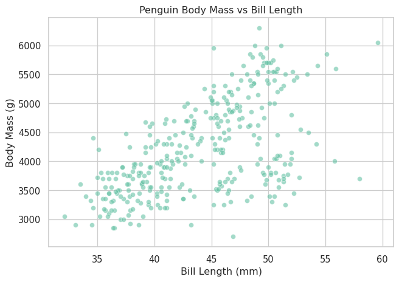

```python
fig, ax = plt.subplots(figsize=(7, 5))
ax.scatter(
    penguins["bill_length_mm"],
    penguins["body_mass_g"],
    alpha=0.6,
    edgecolors="white",
    linewidths=0.5,
)
ax.set_xlabel("Bill Length (mm)")
ax.set_ylabel("Body Mass (g)")
ax.set_title("Penguin Body Mass vs Bill Length")
plt.tight_layout()
plt.show()
```

### Subplots

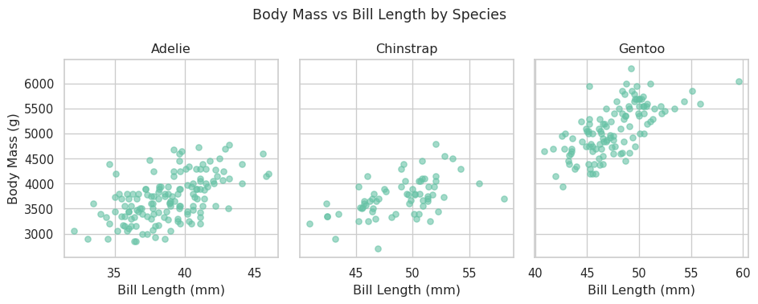

```python
fig, axes = plt.subplots(1, 3, figsize=(10, 4), sharey=True)

for ax, (name, group) in zip(axes, penguins.groupby("species")):
    ax.scatter(group["bill_length_mm"], group["body_mass_g"], alpha=0.6, s=30)
    ax.set_title(name)
    ax.set_xlabel("Bill Length (mm)")

axes[0].set_ylabel("Body Mass (g)")
fig.suptitle("Body Mass vs Bill Length by Species", fontsize=13)
plt.tight_layout()
plt.show()
```

## 4.2 Seaborn — High-Level Statistical Plots

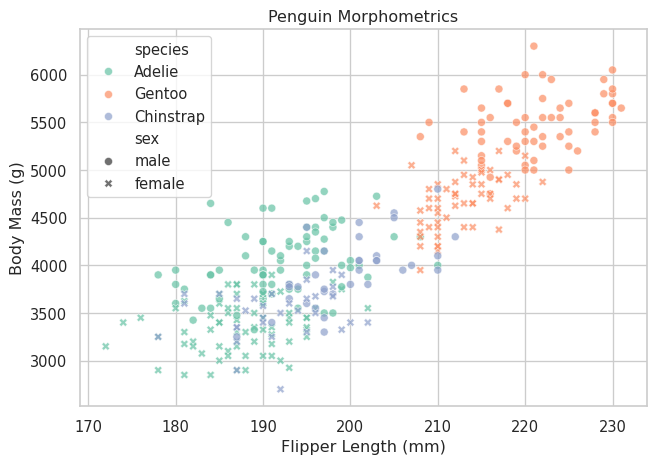

```python
fig, ax = plt.subplots(figsize=(7, 5))
sns.scatterplot(
    data=penguins, x="flipper_length_mm", y="body_mass_g",
    hue="species", style="sex", alpha=0.7, ax=ax,
)
ax.set_xlabel("Flipper Length (mm)")
ax.set_ylabel("Body Mass (g)")
ax.set_title("Penguin Morphometrics")
plt.tight_layout()
plt.show()
```

### Bar Chart

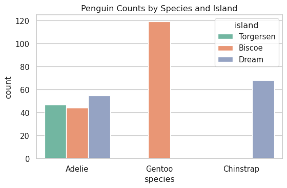

```python
fig, ax = plt.subplots(figsize=(6, 4))
sns.countplot(data=penguins, x="species", hue="island", ax=ax)
ax.set_title("Penguin Counts by Species and Island")
plt.tight_layout()
plt.show()
```

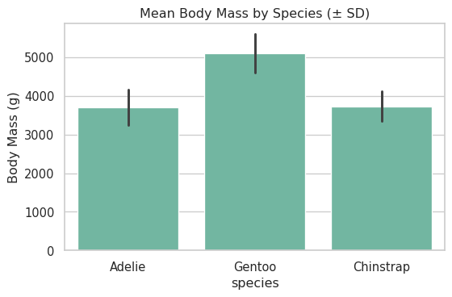

```python
fig, ax = plt.subplots(figsize=(6, 4))
sns.barplot(
    data=penguins, x="species", y="body_mass_g",
    estimator="mean", errorbar="sd", ax=ax,
)
ax.set_ylabel("Body Mass (g)")
ax.set_title("Mean Body Mass by Species (± SD)")
plt.tight_layout()
plt.show()
```

### Histogram and KDE

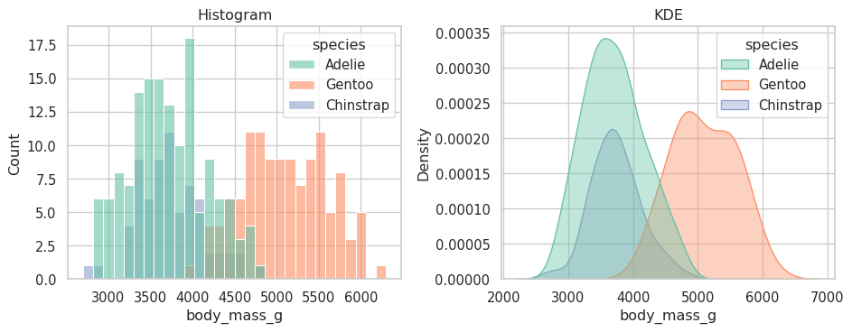

```python
fig, axes = plt.subplots(1, 2, figsize=(10, 4))

sns.histplot(data=penguins, x="body_mass_g", hue="species",
             bins=30, alpha=0.6, ax=axes[0])
axes[0].set_title("Histogram")

sns.kdeplot(data=penguins, x="body_mass_g", hue="species",
            fill=True, alpha=0.4, ax=axes[1])
axes[1].set_title("KDE")

plt.tight_layout()
plt.show()
```

### Box Plot and Violin Plot

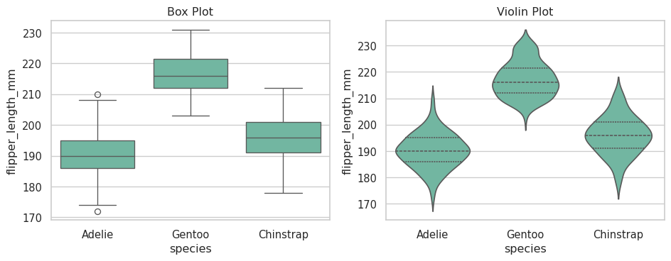

```python
fig, axes = plt.subplots(1, 2, figsize=(10, 4))

sns.boxplot(data=penguins, x="species", y="flipper_length_mm", ax=axes[0])
axes[0].set_title("Box Plot")

sns.violinplot(data=penguins, x="species", y="flipper_length_mm",
               inner="quart", ax=axes[1])
axes[1].set_title("Violin Plot")

plt.tight_layout()
plt.show()
```

### Strip Plot (Jitter)

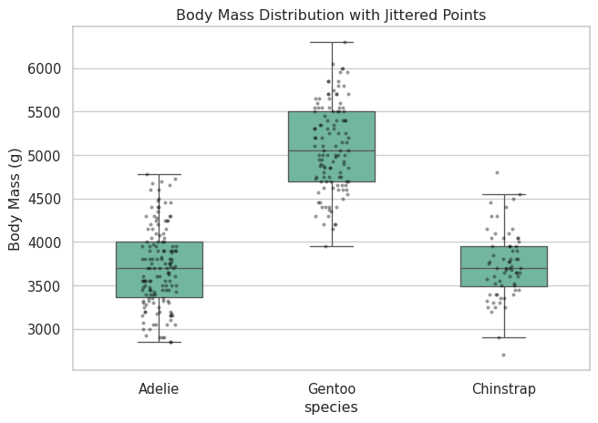

```python
fig, ax = plt.subplots(figsize=(7, 5))
sns.boxplot(data=penguins, x="species", y="body_mass_g", width=0.5,
            fliersize=0, ax=ax)
sns.stripplot(data=penguins, x="species", y="body_mass_g",
              alpha=0.4, size=3, color="black", ax=ax)
ax.set_ylabel("Body Mass (g)")
ax.set_title("Body Mass Distribution with Jittered Points")
plt.tight_layout()
plt.show()
```

### Line Plot

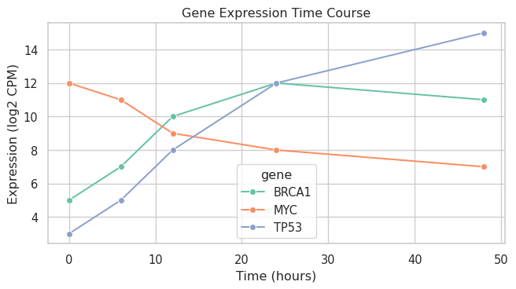

```python
timecourse = pd.DataFrame({
    "time": [0, 6, 12, 24, 48] * 3,
    "gene": sorted(["BRCA1", "TP53", "MYC"] * 5),
    "expr": [5, 7, 10, 12, 11,
             12, 11, 9, 8, 7,
             3, 5, 8, 12, 15],
})

fig, ax = plt.subplots(figsize=(7, 4))
sns.lineplot(data=timecourse, x="time", y="expr", hue="gene",
             marker="o", ax=ax)
ax.set_xlabel("Time (hours)")
ax.set_ylabel("Expression (log2 CPM)")
ax.set_title("Gene Expression Time Course")
plt.tight_layout()
plt.show()
```

### Heatmap

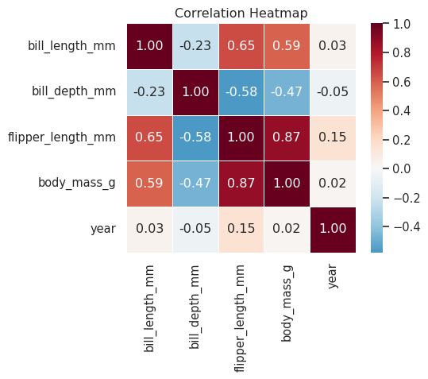

```python
numeric_cols = penguins.select_dtypes(include="number")
corr = numeric_cols.corr()

fig, ax = plt.subplots(figsize=(6, 5))
sns.heatmap(corr, annot=True, fmt=".2f", cmap="RdBu_r", center=0,
            square=True, linewidths=0.5, ax=ax)
ax.set_title("Correlation Heatmap")
plt.tight_layout()
plt.show()
```

### Pair Plot

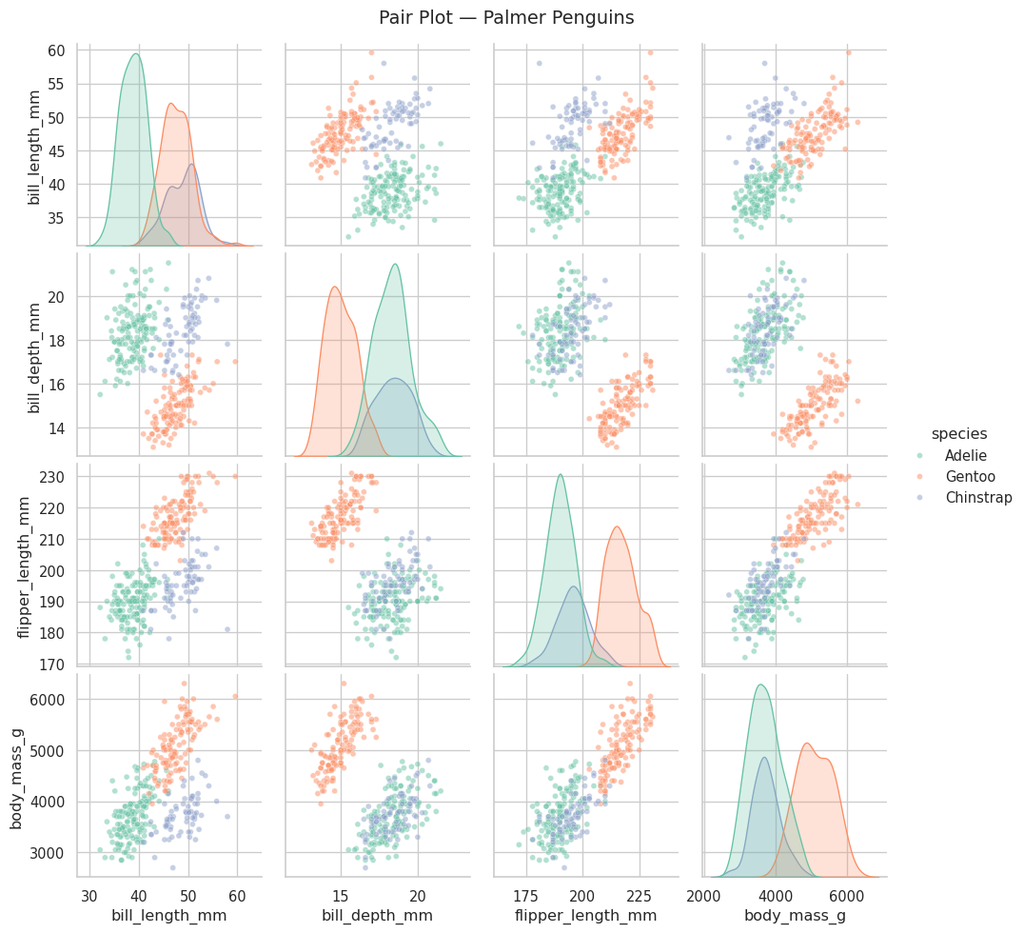

```python
sns.pairplot(
    penguins,
    hue="species",
    vars=["bill_length_mm", "bill_depth_mm", "flipper_length_mm", "body_mass_g"],
    diag_kind="kde",
    plot_kws={"alpha": 0.5, "s": 20},
)
plt.suptitle("Pair Plot — Palmer Penguins", y=1.02)
plt.show()
```

### FacetGrid

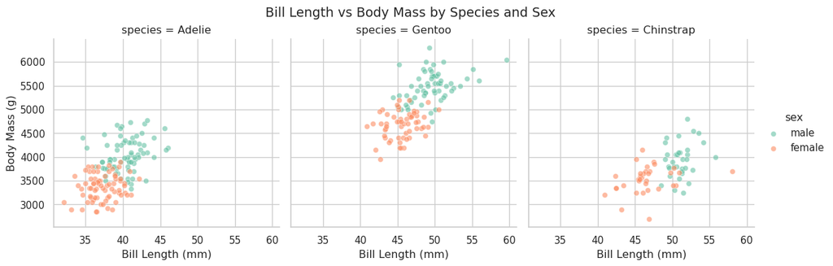

```python
g = sns.FacetGrid(penguins, col="species", hue="sex", height=4, aspect=1)
g.map_dataframe(sns.scatterplot, x="bill_length_mm", y="body_mass_g", alpha=0.6)
g.add_legend()
g.set_axis_labels("Bill Length (mm)", "Body Mass (g)")
g.figure.suptitle("Bill Length vs Body Mass by Species and Sex", y=1.03)
plt.show()
```

### Saving Figures

```python
fig.savefig("my_figure.png", dpi=300, bbox_inches="tight")
fig.savefig("my_figure.pdf", bbox_inches="tight")
```

# Part 5: Statistical Analyses

```python
from scipy import stats
import statsmodels.api as sm
import statsmodels.formula.api as smf
```

## 5.1 Descriptive Statistics

```python
penguins.groupby("species")[["body_mass_g", "bill_length_mm", "flipper_length_mm"]].describe().round(1)
```

| species | body_mass_g count | body_mass_g mean | body_mass_g std | body_mass_g min | body_mass_g 25% | body_mass_g 50% | body_mass_g 75% | body_mass_g max | bill_length_mm count | bill_length_mm mean | bill_length_mm ... | bill_length_mm 75% | bill_length_mm max | flipper_length_mm count | flipper_length_mm mean | flipper_length_mm std | flipper_length_mm min | flipper_length_mm 25% | flipper_length_mm 50% | flipper_length_mm 75% | flipper_length_mm max |
| --- | --- | --- | --- | --- | --- | --- | --- | --- | --- | --- | --- | --- | --- | --- | --- | --- | --- | --- | --- | --- | --- |
| Adelie | 146.0 | 3706.2 | 458.6 | 2850.0 | 3362.5 | 3700.0 | 4000.0 | 4775.0 | 146.0 | 38.8 | ... | 40.8 | 46.0 | 146.0 | 190.1 | 6.5 | 172.0 | 186.0 | 190.0 | 195.0 | 210.0 |
| Chinstrap | 68.0 | 3733.1 | 384.3 | 2700.0 | 3487.5 | 3700.0 | 3950.0 | 4800.0 | 68.0 | 48.8 | ... | 51.1 | 58.0 | 68.0 | 195.8 | 7.1 | 178.0 | 191.0 | 196.0 | 201.0 | 212.0 |
| Gentoo | 119.0 | 5092.4 | 501.5 | 3950.0 | 4700.0 | 5050.0 | 5500.0 | 6300.0 | 119.0 | 47.6 | ... | 49.6 | 59.6 | 119.0 | 217.2 | 6.6 | 203.0 | 212.0 | 216.0 | 221.5 | 231.0 |

3 rows × 24 columns

### Normality Testing

```python
for species, group in penguins.groupby("species"):
    stat, p = stats.shapiro(group["body_mass_g"])
    print(f"{species:>10}: W={stat:.4f}, p={p:.4f}")
```

```
    Adelie: W=0.9812, p=0.0423
 Chinstrap: W=0.9845, p=0.5605
    Gentoo: W=0.9861, p=0.2605
```

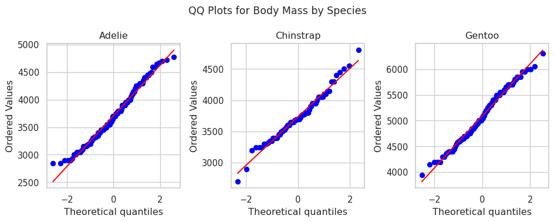

```python
fig, axes = plt.subplots(1, 3, figsize=(10, 4))
for ax, (species, group) in zip(axes, penguins.groupby("species")):
    stats.probplot(group["body_mass_g"], plot=ax)
    ax.set_title(f"{species}")

fig.suptitle("QQ Plots for Body Mass by Species", fontsize=13)
plt.tight_layout()
plt.show()
```

## 5.2 T-Tests

### Two-Sample T-Test

```python
adelie = penguins[penguins["species"] == "Adelie"]["bill_length_mm"]
chinstrap = penguins[penguins["species"] == "Chinstrap"]["bill_length_mm"]

t_stat, p_value = stats.ttest_ind(adelie, chinstrap)
print(f"t = {t_stat:.4f}")
print(f"p = {p_value:.2e}")
```

```
t = -23.5621
p = 3.99e-61
```

### Welch’s T-Test (unequal variances)

```python
t_stat, p_value = stats.ttest_ind(adelie, chinstrap, equal_var=False)
print(f"Welch's t = {t_stat:.4f}")
print(f"p = {p_value:.2e}")
```

```
Welch's t = -21.7125
p = 3.15e-41
```

### Effect Size (Cohen’s d)

```python
def cohens_d(group1, group2):
    """Calculate Cohen's d for two independent groups.

    Args:
        group1: First group values.
        group2: Second group values.

    Returns:
        Cohen's d effect size.
    """
    n1, n2 = len(group1), len(group2)
    pooled_std = np.sqrt(
        ((n1 - 1) * group1.std() ** 2 + (n2 - 1) * group2.std() ** 2)
        / (n1 + n2 - 2)
    )
    return (group1.mean() - group2.mean()) / pooled_std

d = cohens_d(adelie, chinstrap)
print(f"Cohen's d = {d:.4f}")
```

```
Cohen's d = -3.4593
```

### Visualise

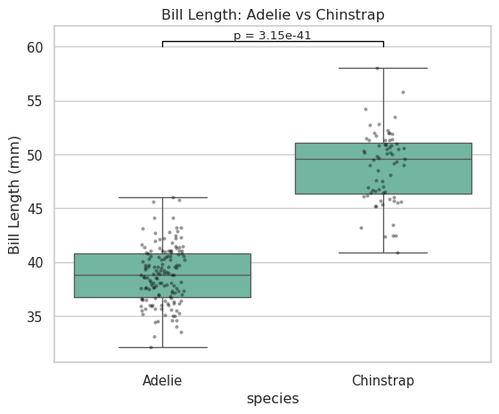

```python
two_sp = penguins[penguins["species"].isin(["Adelie", "Chinstrap"])]

fig, ax = plt.subplots(figsize=(6, 5))
sns.boxplot(data=two_sp, x="species", y="bill_length_mm", ax=ax)
sns.stripplot(data=two_sp, x="species", y="bill_length_mm",
              alpha=0.4, color="black", size=3, ax=ax)

# Annotate significance
y_max = two_sp["bill_length_mm"].max() + 2
ax.plot([0, 0, 1, 1], [y_max, y_max + 0.5, y_max + 0.5, y_max], "k-", lw=1)
ax.text(0.5, y_max + 0.7, f"p = {p_value:.2e}", ha="center", fontsize=10)

ax.set_ylabel("Bill Length (mm)")
ax.set_title("Bill Length: Adelie vs Chinstrap")
plt.tight_layout()
plt.show()
```

## 5.3 ANOVA

### One-Way ANOVA

```python
adelie_mass = penguins[penguins["species"] == "Adelie"]["body_mass_g"]
chinstrap_mass = penguins[penguins["species"] == "Chinstrap"]["body_mass_g"]
gentoo_mass = penguins[penguins["species"] == "Gentoo"]["body_mass_g"]

f_stat, p_value = stats.f_oneway(adelie_mass, chinstrap_mass, gentoo_mass)
print(f"F = {f_stat:.2f}")
print(f"p = {p_value:.2e}")
```

```
F = 341.89
p = 3.74e-81
```

### Using statsmodels (with ANOVA table)

```python
model = smf.ols("body_mass_g ~ C(species)", data=penguins).fit()
anova_table = sm.stats.anova_lm(model, typ=2)
print(anova_table.round(4))
```

```
                  sum_sq     df         F  PR(>F)
C(species)  1.451902e+08    2.0  341.8949     0.0
Residual    7.006945e+07  330.0       NaN     NaN
```

### Post-hoc: Tukey’s HSD

```python
from statsmodels.stats.multicomp import pairwise_tukeyhsd

tukey = pairwise_tukeyhsd(penguins["body_mass_g"], penguins["species"])
print(tukey)
```

```
      Multiple Comparison of Means - Tukey HSD, FWER=0.05
===============================================================
  group1    group2   meandiff p-adj    lower     upper   reject
---------------------------------------------------------------
   Adelie Chinstrap   26.9239 0.9164 -132.3528  186.2005  False
   Adelie    Gentoo 1386.2726    0.0 1252.2897 1520.2554   True
Chinstrap    Gentoo 1359.3487    0.0 1194.4304 1524.2671   True
---------------------------------------------------------------
```

### Check Assumptions: Levene’s Test

```python
stat, p = stats.levene(adelie_mass, chinstrap_mass, gentoo_mass)
print(f"Levene's test: W={stat:.4f}, p={p:.4f}")
```

```
Levene's test: W=5.1349, p=0.0064
```

### Visualise

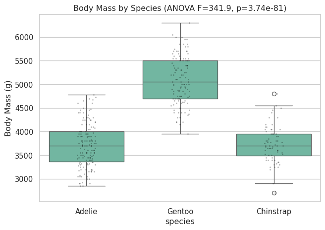

```python
fig, ax = plt.subplots(figsize=(7, 5))
sns.boxplot(data=penguins, x="species", y="body_mass_g", ax=ax)
sns.stripplot(data=penguins, x="species", y="body_mass_g",
              alpha=0.3, color="black", size=2, ax=ax)

ax.set_ylabel("Body Mass (g)")
ax.set_title(f"Body Mass by Species (ANOVA F={f_stat:.1f}, p={p_value:.2e})")
plt.tight_layout()
plt.show()
```

## 5.4 Correlation

```python
# Pearson correlation
r, p = stats.pearsonr(penguins["bill_length_mm"], penguins["body_mass_g"])
print(f"Pearson r = {r:.4f}, p = {p:.2e}")

# Spearman rank correlation
rho, p_spear = stats.spearmanr(penguins["bill_length_mm"], penguins["body_mass_g"])
print(f"Spearman ρ = {rho:.4f}, p = {p_spear:.2e}")
```

```
Pearson r = 0.5895, p = 1.54e-32
Spearman ρ = 0.5765, p = 6.97e-31
```

### Correlation Matrix

```python
corr_mat = numeric_cols.corr()
p_mat = numeric_cols.corr(method=lambda x, y: stats.pearsonr(x, y)[1])

print("Correlation coefficients:")
print(corr_mat.round(3))
print("\nP-values:")
print(p_mat.round(4))
```

```
Correlation coefficients:
                   bill_length_mm  bill_depth_mm  flipper_length_mm  \
bill_length_mm              1.000         -0.229              0.653
bill_depth_mm              -0.229          1.000             -0.578
flipper_length_mm           0.653         -0.578              1.000
body_mass_g                 0.589         -0.472              0.873
year                        0.033         -0.048              0.151

                   body_mass_g   year
bill_length_mm           0.589  0.033
bill_depth_mm           -0.472 -0.048
flipper_length_mm        0.873  0.151
body_mass_g              1.000  0.022
year                     0.022  1.000

P-values:
                   bill_length_mm  bill_depth_mm  flipper_length_mm  \
bill_length_mm             1.0000         0.0000             0.0000
bill_depth_mm              0.0000         1.0000             0.0000
flipper_length_mm          0.0000         0.0000             1.0000
body_mass_g                0.0000         0.0000             0.0000
year                       0.5526         0.3808             0.0057

                   body_mass_g    year
bill_length_mm           0.000  0.5526
bill_depth_mm            0.000  0.3808
flipper_length_mm        0.000  0.0057
body_mass_g              1.000  0.6910
year                     0.691  1.0000
```

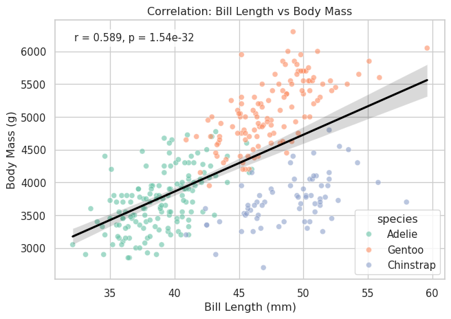

```python
fig, ax = plt.subplots(figsize=(7, 5))
sns.scatterplot(data=penguins, x="bill_length_mm", y="body_mass_g",
                hue="species", alpha=0.6, ax=ax)
sns.regplot(data=penguins, x="bill_length_mm", y="body_mass_g",
            scatter=False, color="black", ax=ax)
ax.text(
    0.05, 0.95, f"r = {r:.3f}, p = {p:.2e}",
    transform=ax.transAxes, fontsize=11,
    verticalalignment="top",
    bbox=dict(boxstyle="round", facecolor="white", alpha=0.8),
)
ax.set_xlabel("Bill Length (mm)")
ax.set_ylabel("Body Mass (g)")
ax.set_title("Correlation: Bill Length vs Body Mass")
plt.tight_layout()
plt.show()
```

## 5.5 Linear Regression

### Simple Linear Regression

```python
model = smf.ols("body_mass_g ~ bill_length_mm", data=penguins).fit()
print(model.summary())
```

```
                            OLS Regression Results
==============================================================================
Dep. Variable:            body_mass_g   R-squared:                       0.347
Model:                            OLS   Adj. R-squared:                  0.345
Method:                 Least Squares   F-statistic:                     176.2
Date:                Fri, 13 Mar 2026   Prob (F-statistic):           1.54e-32
Time:                        21:35:03   Log-Likelihood:                -2629.1
No. Observations:                 333   AIC:                             5262.
Df Residuals:                     331   BIC:                             5270.
Df Model:                           1
Covariance Type:            nonrobust
==================================================================================
                     coef    std err          t      P>|t|      [0.025      0.975]
----------------------------------------------------------------------------------
Intercept        388.8452    289.817      1.342      0.181    -181.271     958.961
bill_length_mm    86.7918      6.538     13.276      0.000      73.931      99.652
==============================================================================
Omnibus:                        6.141   Durbin-Watson:                   0.849
Prob(Omnibus):                  0.046   Jarque-Bera (JB):                4.899
Skew:                          -0.197   Prob(JB):                       0.0864
Kurtosis:                       2.555   Cond. No.                         360.
==============================================================================

Notes:
[1] Standard Errors assume that the covariance matrix of the errors is correctly specified.
```

### Tidy Coefficients

```python
coef_df = pd.DataFrame({
    "term": model.params.index,
    "estimate": model.params.values,
    "std_error": model.bse.values,
    "t_value": model.tvalues.values,
    "p_value": model.pvalues.values,
    "conf_low": model.conf_int()[0].values,
    "conf_high": model.conf_int()[1].values,
})
coef_df.round(4)
```

|  | term | estimate | std_error | t_value | p_value | conf_low | conf_high |
| --- | --- | --- | --- | --- | --- | --- | --- |
| 0 | Intercept | 388.8452 | 289.8172 | 1.3417 | 0.1806 | -181.2707 | 958.9610 |
| 1 | bill_length_mm | 86.7918 | 6.5377 | 13.2756 | 0.0000 | 73.9311 | 99.6524 |

### Multiple Regression

```python
model_multi = smf.ols(
    "body_mass_g ~ bill_length_mm + flipper_length_mm + C(species)",
    data=penguins,
).fit()

print(f"R² = {model_multi.rsquared:.4f}")
print(f"Adj. R² = {model_multi.rsquared_adj:.4f}")
print(f"AIC = {model_multi.aic:.1f}")
print()

# Coefficients
coef_multi = pd.DataFrame({
    "estimate": model_multi.params,
    "std_error": model_multi.bse,
    "p_value": model_multi.pvalues,
}).round(4)
coef_multi
```

```
R² = 0.8243
Adj. R² = 0.8222
AIC = 4831.2
```

|  | estimate | std_error | p_value |
| --- | --- | --- | --- |
| Intercept | -3864.0732 | 533.5921 | 0.0000 |
| C(species)[T.Chinstrap] | -732.4167 | 82.0634 | 0.0000 |
| C(species)[T.Gentoo] | 113.2542 | 89.2056 | 0.2051 |
| bill_length_mm | 60.1173 | 7.2071 | 0.0000 |
| flipper_length_mm | 27.5443 | 3.2093 | 0.0000 |

### Diagnostic Plots

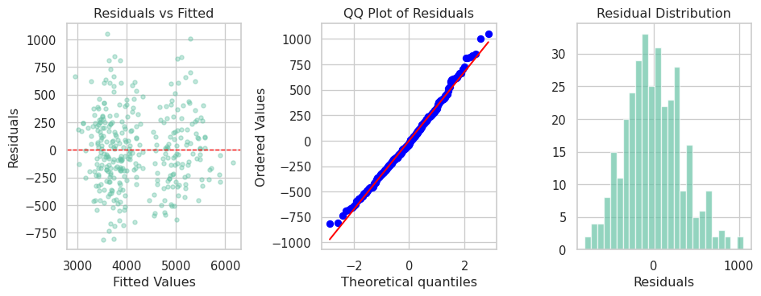

```python
fig, axes = plt.subplots(1, 3, figsize=(10, 4))

residuals = model_multi.resid
fitted = model_multi.fittedvalues

# Residuals vs Fitted
axes[0].scatter(fitted, residuals, alpha=0.4, s=15)
axes[0].axhline(0, color="red", linestyle="--", linewidth=1)
axes[0].set_xlabel("Fitted Values")
axes[0].set_ylabel("Residuals")
axes[0].set_title("Residuals vs Fitted")

# QQ plot
stats.probplot(residuals, plot=axes[1])
axes[1].set_title("QQ Plot of Residuals")

# Histogram of residuals
axes[2].hist(residuals, bins=25, edgecolor="white", alpha=0.7)
axes[2].set_xlabel("Residuals")
axes[2].set_title("Residual Distribution")

plt.tight_layout()
plt.show()
```

## 5.6 Chi-Square Test

Test whether species distribution is independent of island:

```python
contingency = pd.crosstab(penguins["species"], penguins["island"])
print(contingency)
print()

chi2, p, dof, expected = stats.chi2_contingency(contingency)
print(f"χ² = {chi2:.2f}")
print(f"p = {p:.2e}")
print(f"df = {dof}")
```

```
island     Biscoe  Dream  Torgersen
species
Adelie         44     55         47
Chinstrap       0     68          0
Gentoo        119      0          0

χ² = 284.59
p = 2.28e-60
df = 4
```

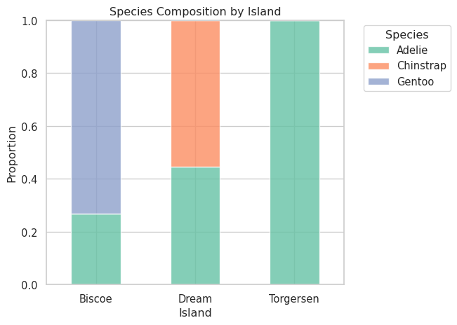

```python
fig, ax = plt.subplots(figsize=(7, 5))

# Proportional stacked bar
ct_norm = contingency.div(contingency.sum(axis=0), axis=1)
ct_norm.T.plot(kind="bar", stacked=True, ax=ax, alpha=0.8)

ax.set_ylabel("Proportion")
ax.set_xlabel("Island")
ax.set_title("Species Composition by Island")
ax.legend(title="Species", bbox_to_anchor=(1.05, 1))
plt.xticks(rotation=0)
plt.tight_layout()
plt.show()
```

# Summary

| Topic | Key Functions / Methods |
| --- | --- |
| **Data types** | `type()`, `int()`, `float()`, `str()`, `bool()` |
| **Lists** | `append()`, `extend()`, `sort()`, list comprehensions |
| **Dicts** | `dict[key]`, `.get()`, `.items()`, dict comprehensions |
| **Sets** | `&`, `\\|`, `-`, `in` |
| **NumPy** | `np.array()`, `np.arange()`, `.mean()`, `.reshape()` |
| **Read data** | `pd.read_csv()`, `pd.read_excel()`, `sep="\t"` |
| **Filter rows** | `df[condition]`, `.query()`, `.isin()`, `.between()` |
| **Select columns** | `df[["col"]]`, `.loc[]`, `.iloc[]` |
| **Transform** | `.assign()`, `np.select()`, `.str` accessor |
| **Aggregate** | `.groupby()`, `.agg()`, `.describe()` |
| **Reshape** | `.melt()`, `.pivot_table()`, `.str.split()` |
| **Join** | `pd.merge()`, `how="left/inner/outer"` |
| **Matplotlib** | `fig, ax = plt.subplots()`, `ax.scatter()`, `ax.set_*()` |
| **Seaborn** | `sns.scatterplot()`, `sns.boxplot()`, `sns.heatmap()` |
| **T-test** | `stats.ttest_ind()`, `equal_var=False` |
| **ANOVA** | `stats.f_oneway()`, `sm.stats.anova_lm()`, `pairwise_tukeyhsd()` |
| **Correlation** | `stats.pearsonr()`, `stats.spearmanr()`, `.corr()` |
| **Regression** | `smf.ols().fit()`, `.summary()`, `.params`, `.conf_int()` |
| **Chi-square** | `stats.chi2_contingency()`, `pd.crosstab()` |

## Next Steps

- **Scikit-learn**: Machine learning (classification, regression, clustering)
- **Biopython**: Sequence analysis, BLAST, GenBank parsing
- **Scanpy / AnnData**: Single-cell RNA-seq analysis
- **Python Data Science Handbook**: Free online at [jakevdp.github.io/PythonDataScienceHandbook](https://jakevdp.github.io/PythonDataScienceHandbook/)